Bennett Widyolar  
ES 207 - HW #2  
2/18/2016

# Homework Assignment 2

## Objective

As a “quick” back of the envelope exercise, I will develop a short report showing the location of project sites, testing the assumption that the project sites are independent of each other in frequency of trees present in sample plots. Due to the large # of species, a subsample of the 5 most frequent will suffice for this preliminary assessment.

## Methods

I will be using R as the programming language to analylze the data and the Chi-Squared test to determine independence.

## Data

The data for this study came from the ES 207 HW2 folder. Species name, woody stem diameter and height were collected along with longitude and latitude data. This data is ultimately to be used to estimate carbon density at each site.

## Code

The code for this project is as follows:

```r
rm(list=ls())

ripdata <- read.csv("riparian_survey.csv")

#CREATE NEW PROJECT CODE COLUMN
oldvals <- levels(ripdata$ProjectID)
newvals <- factor(c("COSRP", "HEROW", "NAPSO", "SACTO"))
ripdata$ProjCode <- newvals[match(ripdata$ProjectID, oldvals)]

#REMOVE UNNECESSARY DATA
ripdata <- ripdata[-c(which(ripdata$SpeciesVarietalName == "Unknown")), ]
ripdata <- ripdata[-c(which(ripdata$SpeciesVarietalName == "Not Recorded")), ]
ripdata <- ripdata[-c(which(ripdata$SpeciesVarietalName == "dead wood")), ]
ripdata <- droplevels(ripdata)

#PROJECT LOCATION SUMMARY FOR EACH SITE
ProjLoc <- aggregate(cbind(Latitude,Longitude) ~ ProjCode, data=ripdata, mean)

#ADD PLANT GENUS COLUMN FACTOR AND PLOT FREQUENCY DISTRIBUTION
ripdata$Genus = as.factor(sapply(strsplit(as.character(ripdata$SpeciesVarietalName), " "), "[[", 1))
temp <- sort(summary(ripdata$Genus))
barplot(sort(summary(ripdata$Genus)), las=2)
top5 <- temp[(length(temp)-5+1):length(temp)]
rm(temp)
rm(top5)

top5 <- ripdata[c(which(ripdata$Genus == "Fraxinus")),]
top5 <- rbind(top5,ripdata[c(which(ripdata$Genus == "Acer")),])
top5 <- rbind(top5,ripdata[c(which(ripdata$Genus == "Quercus")),])
top5 <- rbind(top5,ripdata[c(which(ripdata$Genus == "Populus")),])
top5 <- rbind(top5,ripdata[c(which(ripdata$Genus == "Salix")),])
top5 <- droplevels(top5)

#TEST FOR INDEPENDENCE
ind_table <- table(top5$Genus,top5$ProjCode)
chisq.test(ind_table)

#PLOT MAP
plot(ProjLoc[1,3],ProjLoc[1,2],pch=15,main="Project Locations",xlab="Longitude",ylab="Latitude",xlim=c(-123,-121),ylim=c(37,41))
points(ProjLoc[2,3],ProjLoc[2,2],pch=0)
points(ProjLoc[3,3],ProjLoc[3,2],pch=8)
points(ProjLoc[4,3],ProjLoc[4,2],pch=24)
legend("topright",title="Project Sites",c("COSRP","HEROW","NAPSO","SACTO"),pch=c(15,0,8,24),inset=0.05)
grid(10,10)
write.csv(top5,file="top5_dataset.csv")
```

## Results

The following is a species frequency table for all sites tested:

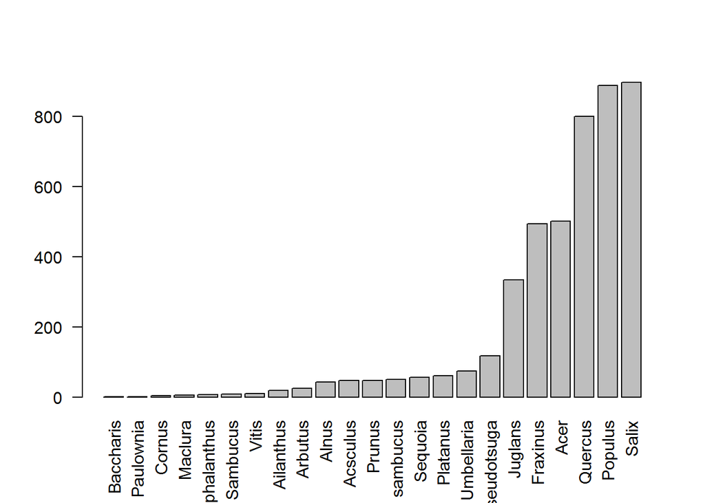

The top 5 species and their frequency at each site are shown in the table below.

```
##
##            COSRP HEROW NAPSO SACTO
##   Acer       155    24   105   218
##   Fraxinus   421     7    21    46
##   Populus    604   109    85    91
##   Quercus    736    14    11    40
##   Salix      587   123    56   132
```

The Chi-Squared test for independence results for this table are shown below.

```
##
##  Pearson's Chi-squared test
##
## data:  ind_table
## X-squared = 841.18, df = 12, p-value < 2.2e-16
```

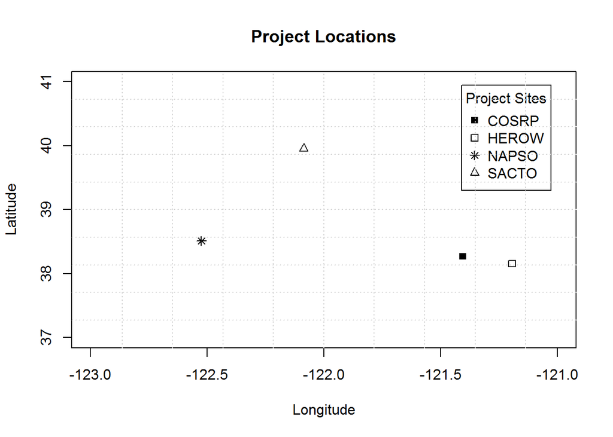

## Discussion

The p-value of the Chi-Squared independence test is extremely low. Thus I must reject the null hypothesis that the frequency of trees at a given site is independent of project site. In fact, the types of trees and frequency distribution of these trees is highly dependent on the site you are at.

## Limitations

Simplification: I am performing this analysis based on the 5 most common genera from the entire species list. Data: The woody dbh does not measure anything less than 1 cm and the woody height does not measure less than 0.034 meters.